# AllState

```python
import pandas as pd
import numpy as np
from sklearn.preprocessing import StandardScaler
import matplotlib.pyplot as plt

# Print all rows and columns. Dont hide any
pd.set_option('display.max_rows', None)
pd.set_option('display.max_columns', None)

# Disable SettingWithCopyWarning
pd.options.mode.chained_assignment = None  # default='warn'

# Use this seed for all random states
seed = 0

# for data preprocessing using normalization
scaler_x = StandardScaler()
scaler_y = StandardScaler()
```

```python
# XGBoost bug hot-fix:
# XGBoost cannot predict large test dataset at one go, so we divide test set into small chuck

def getPred(model,X_val):
    chunk = 5000  #chunk row size
    X_val_chunks = [X_val[i:i+chunk] for i in range(0,X_val.shape[0],chunk)]

    pred = []
    for X_val_chunk in X_val_chunks:
        pred.append(model.predict(X_val_chunk))
    pred = np.concatenate(pred)
    return pred
```

## Load raw data:

- In this step, we save `'ID'` column for test set so we can construct `submission.csv` file after prediction.

```python
raw_train = pd.read_csv("../data/train.csv")
raw_test = pd.read_csv("../data/test.csv")

# Save the id's for submission file
ID = raw_test['id']

# drop 'id' column
raw_train.drop('id',axis=1, inplace=True)
raw_test.drop('id',axis=1, inplace=True)

#Display the first row to get a feel of the data
print(raw_train.head(1))
```

```
  cat1 cat2 cat3 cat4 cat5 cat6 cat7 cat8 cat9 cat10 cat11 cat12 cat13 cat14  \
0    A    B    A    B    A    A    A    A    B     A     B     A     A     A

  cat15 cat16 cat17 cat18 cat19 cat20 cat21 cat22 cat23 cat24 cat25 cat26  \
0     A     A     A     A     A     A     A     A     B     A     A     A

  cat27 cat28 cat29 cat30 cat31 cat32 cat33 cat34 cat35 cat36 cat37 cat38  \
0     A     A     A     A     A     A     A     A     A     A     A     A

  cat39 cat40 cat41 cat42 cat43 cat44 cat45 cat46 cat47 cat48 cat49 cat50  \
0     A     A     A     A     A     A     A     A     A     A     A     A

  cat51 cat52 cat53 cat54 cat55 cat56 cat57 cat58 cat59 cat60 cat61 cat62  \
0     A     A     A     A     A     A     A     A     A     A     A     A

  cat63 cat64 cat65 cat66 cat67 cat68 cat69 cat70 cat71 cat72 cat73 cat74  \
0     A     A     A     A     A     A     A     A     A     A     A     A

  cat75 cat76 cat77 cat78 cat79 cat80 cat81 cat82 cat83 cat84 cat85 cat86  \
0     B     A     D     B     B     D     D     B     D     C     B     D

  cat87 cat88 cat89 cat90 cat91 cat92 cat93 cat94 cat95 cat96 cat97 cat98  \
0     B     A     A     A     A     A     D     B     C     E     A     C

  cat99 cat100 cat101 cat102 cat103 cat104 cat105 cat106 cat107 cat108 cat109  \
0     T      B      G      A      A      I      E      G      J      G     BU

  cat110 cat111 cat112 cat113 cat114 cat115 cat116   cont1     cont2  \
0     BC      C     AS      S      A      O     LB  0.7263  0.245921

      cont3     cont4     cont5     cont6    cont7   cont8    cont9  cont10  \
0  0.187583  0.789639  0.310061  0.718367  0.33506  0.3026  0.67135  0.8351

     cont11    cont12    cont13    cont14     loss
0  0.569745  0.594646  0.822493  0.714843  2213.18
```

## Split dataset:

- index 0 - 115 are category
- index 116(included) onwards are numerical

```python
#scaler = StandardScaler().fit(raw_train)
last_discrete_idx = 116

raw_train_discrete = raw_train.iloc[:,:last_discrete_idx]
raw_train_continuous = raw_train.iloc[:,last_discrete_idx:-1]
raw_trainY = raw_train[['loss']]

raw_test_discrete = raw_test.iloc[:,:last_discrete_idx]
raw_test_continuous = raw_test.iloc[:,last_discrete_idx:]
```

## Data statistics:

- Shape
- Description
- Skew

```python
temp = pd.concat([raw_train_discrete, raw_train_continuous, raw_trainY], axis=1)

print(temp.shape)
# Observe that means are 0s and standard deviations are 1s
print(temp.describe())
#print(temp.skew())
```

```
(188318, 131)
               cont1          cont2          cont3          cont4  \
count  188318.000000  188318.000000  188318.000000  188318.000000
mean        0.493861       0.507188       0.498918       0.491812
std         0.187640       0.207202       0.202105       0.211292
min         0.000016       0.001149       0.002634       0.176921
25%         0.346090       0.358319       0.336963       0.327354
50%         0.475784       0.555782       0.527991       0.452887
75%         0.623912       0.681761       0.634224       0.652072
max         0.984975       0.862654       0.944251       0.954297

               cont5          cont6          cont7          cont8  \
count  188318.000000  188318.000000  188318.000000  188318.000000
mean        0.487428       0.490945       0.484970       0.486437
std         0.209027       0.205273       0.178450       0.199370
min         0.281143       0.012683       0.069503       0.236880
25%         0.281143       0.336105       0.350175       0.312800
50%         0.422268       0.440945       0.438285       0.441060
75%         0.643315       0.655021       0.591045       0.623580
max         0.983674       0.997162       1.000000       0.980200

               cont9         cont10         cont11         cont12  \
count  188318.000000  188318.000000  188318.000000  188318.000000
mean        0.485506       0.498066       0.493511       0.493150
std         0.181660       0.185877       0.209737       0.209427
min         0.000080       0.000000       0.035321       0.036232
25%         0.358970       0.364580       0.310961       0.311661
50%         0.441450       0.461190       0.457203       0.462286
75%         0.566820       0.614590       0.678924       0.675759
max         0.995400       0.994980       0.998742       0.998484

              cont13         cont14           loss
count  188318.000000  188318.000000  188318.000000
mean        0.493138       0.495717    3037.337686
std         0.212777       0.222488    2904.086186
min         0.000228       0.179722       0.670000
25%         0.315758       0.294610    1204.460000
50%         0.363547       0.407403    2115.570000
75%         0.689974       0.724623    3864.045000
max         0.988494       0.844848  121012.250000
```

## Data Transformation:

- Skew correction
- We use `log shift` method to improve the skewness of the `'loss'` column
- We try shift values [0, 1, 10, 100, 500, 1000] and plot the graph of it.

**Result:**

- Best shift is 0

**Take Note:**

- We have to use `np.exp()` later to convert back the `'loss'` after prediction

```
Skewness without log shift: 3.7949583775378604
Best shift: 0
Skewness with log shift: 0.09297454555136214
```

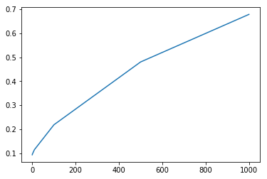

```python
temp = raw_trainY['loss']
original_skew = temp.skew()
print('Skewness without log shift: ' + str(original_skew))

shifts = [0, 1, 10, 100, 500, 1000]
temp_result = []

for shift in shifts:
    shifted = np.log(temp + shift)
    temp_result.append(shifted.skew())

val, idx = min((val, idx) for (idx, val) in enumerate(temp_result))
best_shift = shifts[idx]

print('Best shift: ' + str(shifts[idx]))
print('Skewness with log shift: ' + str(val))

plt.plot(shifts, temp_result)
plt.show()

raw_trainY['loss'] = np.log(raw_trainY['loss'] + best_shift)
```

## Data Pre Processing:

- Normalization (Z-Scoring)

**Take Note:**

- We split data to X (all the features) and Y (loss) and perform normalization separately. This is so that we can use `scaler_y` to inverse transform the prediction of loss later.
- We only use the train set to fit the normalization.

```python
scaler_x.fit(raw_train_continuous)
scaler_y.fit(raw_trainY)

# Save columns name
col_name_X = raw_train_continuous.columns.values
col_name_Y = raw_trainY.columns.values

# transform
clean_train_continuous = scaler_x.transform(raw_train_continuous)
clean_trainY = scaler_y.transform(raw_trainY)
clean_test_continuous = scaler_x.transform(raw_test_continuous)

clean_train_continuous = pd.DataFrame(data=clean_train_continuous, columns=col_name_X)
clean_trainY = pd.DataFrame(data=clean_trainY, columns=col_name_Y)
clean_test_continuous = pd.DataFrame(data=clean_test_continuous, columns=col_name_X)
```

## Data Visualization:

- Categorical attributes
- It can be observed that cat1 to 98 have significantly less number of categories than cat99 to 116.

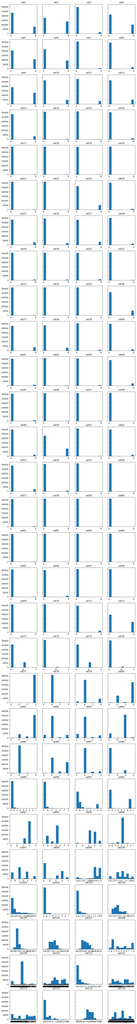

```python
# Count of each label in each category
try:
    count_result = pd.read_pickle('../intermediate/count_result')
except FileNotFoundError:
    temp = pd.concat([raw_train_discrete, raw_test_discrete])
    count_result = temp.apply(pd.value_counts)
    count_result.to_pickle('../intermediate/count_result')

#names of all the columns
cols = count_result.columns

# Plot count plot for all attributes in a 29x4 grid
n_cols = 4
n_rows = 29
fig, axes = plt.subplots(n_rows, n_cols, sharey=True, figsize=(12, 100))
for i in range(n_rows):
    for j in range(n_cols):
        col_name = cols[i*n_cols+j]
        temp = count_result[col_name]
        temp = temp.dropna()
        axes[i, j].hist(temp.index.values.tolist(), weights=temp.tolist())
        axes[i, j].set_title(col_name)
plt.savefig('../intermediate/count_plot.png', dpi=100)
```

## Feature Engineering:

### Motivation:

- Using One-Hot encoding to all categorical data may increase the number of features substantially and this requires long computational time ### Approach:
- For features with small number of categories (cat1-98), we use one-hot encoding
- For features with large number of categories (cat99-116), we use ordinal encoding

```python
n_train = raw_train_discrete.shape[0]
n_test = raw_test_discrete.shape[0]

split = 98

one_hot_train = raw_train_discrete.iloc[:,:split]
one_hot_test = raw_test_discrete.iloc[:,:split]
one_hot_temp = pd.concat([one_hot_train, one_hot_test])

ordinal_train = raw_train_discrete.iloc[:,split:]
ordinal_test = raw_test_discrete.iloc[:,split:]
ordinal_temp = pd.concat([ordinal_train, ordinal_test])

# One-Hot encoding
one_hot_temp = pd.get_dummies(one_hot_temp)
# Ordinal encoding
from sklearn.preprocessing import LabelEncoder
ordinal_temp = ordinal_temp.apply(LabelEncoder().fit_transform)

encoded = pd.concat([one_hot_temp, ordinal_temp], axis=1)

print(encoded.shape)

raw_train_discrete_encoded = encoded.iloc[:n_train,:]
raw_test_discrete_encoded = encoded.iloc[n_train:,:]
```

```
(313864, 293)
```

## Data Preparation:

- Split into train and validation
- We use K-Fold method with k = 5
- We also declare `mean_absolute_error` as a scoring parameter

```python
XY_train = pd.concat([raw_train_discrete_encoded, clean_train_continuous, clean_trainY], axis=1)
X_test = pd.concat([raw_test_discrete_encoded, clean_test_continuous], axis=1)

print('Number of dataset: ')
print('Train: ' + str(XY_train.shape[0]))
print('Test: ' + str(X_test.shape[0]))

from sklearn.model_selection import KFold
kf = KFold(n_splits=5, random_state=seed, shuffle=False)

# Scoring parameter
from sklearn.metrics import mean_absolute_error
```

```
Number of dataset:
Train: 188318
Test: 125546
```

## Artificial Neural Network (ANN):

- We use keras with Tensorflow backend here
- The ANN we considered are baseline, small, deeper, custom
- We use epoch (training round) = 30

```python
# This list will contain ANN models
nn_models = []

try:

    r,c = XY_train.shape
    #Import libraries for deep learning
    from keras.wrappers.scikit_learn import KerasRegressor
    from keras.models import Sequential
    from keras.layers import Dense, Dropout, Activation
    from keras.layers.normalization import BatchNormalization
    from keras.layers.advanced_activations import PReLU

    # define baseline model
    def baseline(v):
        # create model
        model = Sequential()
        model.add(Dense(v*(c-1), input_dim=v*(c-1), kernel_initializer='normal', activation='relu'))
        model.add(Dense(1, kernel_initializer='normal'))
        # Compile model
        model.compile(loss='mean_absolute_error', optimizer='adam')
        return model

    # define smaller model
    def smaller(v):
        # create model
        model = Sequential()
        model.add(Dense(v*(c-1)//2, input_dim=v*(c-1), kernel_initializer='normal', activation='relu'))
        model.add(Dense(1, kernel_initializer='normal', activation='relu'))
        # Compile model
        model.compile(loss='mean_absolute_error', optimizer='adam')
        return model

    # define deeper model
    def deeper(v):
        # create model
        model = Sequential()
        model.add(Dense(v*(c-1), input_dim=v*(c-1), kernel_initializer='normal', activation='relu'))
        model.add(Dense(v*(c-1)//2, kernel_initializer='normal', activation='relu'))
        model.add(Dense(1, kernel_initializer='normal', activation='relu'))
        # Compile model
        model.compile(loss='mean_absolute_error', optimizer='adam')
        return model

    # custom neural net
    def custom(v):
        model = Sequential()

        model.add(Dense(250, input_dim = c-1, kernel_initializer = 'normal'))
        model.add(Dense(100, kernel_initializer = 'normal', activation='relu'))
        model.add(Dense(50, kernel_initializer = 'normal', activation='relu'))

        model.add(Dense(1, kernel_initializer = 'normal', activation='relu'))
        model.compile(loss = 'mean_absolute_error', optimizer = 'adam')
        return(model)

    est_list = [('MLP',baseline),('smaller',smaller),('deeper',deeper),('custom', custom)]

    for name, est in est_list:

        temp = {}
        temp['name'] = name
        temp['model'] = KerasRegressor(build_fn=est, v=1, nb_epoch=30, verbose=0)

        nn_models.append(temp)

except ModuleNotFoundError:
    print('Tensorflow is not installed with GUP support')
```

```
Tensorflow is not installed with GUP support
```

## Tuning XGBoost hyperparameters:

During this step, we fist find the best n_estimators for different max_depth for max_depth = [5,6,7,8].

- max_depth
- n_estimators

```python
xgb_dn_models = []

try:
    from xgboost import XGBRegressor

    dn_list = [
        (8,[230,240,250]),
        (7,[280,300,320]),
        (6,[380,400,420]),
        (5,[760,780,800])
    ]

    for d, n_list in dn_list:
        for n in n_list:

            model = XGBRegressor(n_estimators=n, seed=seed, tree_method='gpu_hist', max_depth=d, gamma=3, min_child_weight=3, learning_rate=0.09)

            temp = {}
            temp['name'] = "XGB-d" + str(d) + "-n" + str(n)
            temp['model'] = model

            xgb_dn_models.append(temp)

except ModuleNotFoundError:
    print('XGBoost is not installed with GUP support')
```

```
XGBoost is not installed with GUP support
```

## Tuning XGBoost hyperparameters:

For different max_depth, we tune the value of gamma parameter.

- gamma

```python
xgb_g_models = []
try:
    from xgboost import XGBRegressor

    gamma_list = np.array([0, 1, 3])

    dn_list = [
        (8,240),
        (7,280),
        (6,400),
        (5,780)
    ]

    for d,n in dn_list:
        for gamma in gamma_list:

            model = XGBRegressor(n_estimators=n, seed=seed, tree_method='gpu_hist', max_depth=d, min_child_weight=3, gamma=gamma, learning_rate=0.09)

            temp = {}
            temp['name'] = "XGB-d" + str(d) + "-n" + str(n) + "-g" + str(gamma)
            temp['model'] = model

            xgb_g_models.append(temp)
except ModuleNotFoundError:
    print('XGBoost is not installed with GUP support')
```

```
XGBoost is not installed with GUP support
```

## Tuning XGBoost hyperparameters:

For different max_depth, we tune the value of min_child_weight parameter.

- min_child_weight

```python
xgb_mcw_models = []
try:
    from xgboost import XGBRegressor

    mcw_list = np.array([2, 3, 4, 5])

    dng_list = [
        (8,240,3),
        (7,280,0),
        (6,400,3),
        (5,780,0)
    ]

    for d,n,g in dng_list:
        for mcw in mcw_list:

            model = XGBRegressor(n_estimators=n, seed=seed, tree_method='gpu_hist', max_depth=d, gamma=g, min_child_weight=mcw, learning_rate=0.09)

            temp = {}
            temp['name'] = "XGB-d" + str(d) + "-mcw" + str(mcw)
            temp['model'] = model

            xgb_mcw_models.append(temp)

except ModuleNotFoundError:
    print('XGBoost is not installed with GUP support')
```

```
XGBoost is not installed with GUP support
```

## Tuning XGBoost hyperparameters:

For different max_depth, we tune the value of learning_rate parameter.

- learning rate

```python
xgb_lr_models = []
try:
    from xgboost import XGBRegressor

    lr_list = np.array([0.08, 0.09, 0.1])

    dng_list = [
        (8,240,3,5),
        (7,280,0,5),
        (6,400,3,4),
        (5,780,0,5)
    ]

    for d,n,g,mcw in dng_list:
        for lr in lr_list:

            model = XGBRegressor(n_estimators=n, seed=seed, tree_method='gpu_hist', max_depth=d, gamma=g, min_child_weight=mcw, learning_rate=lr)

            temp = {}
            temp['name'] = "XGB-d" + str(d) + "-lr" + str(lr)
            temp['model'] = model

            xgb_lr_models.append(temp)
except ModuleNotFoundError:
    print('XGBoost is not installed with GUP support')
```

```
XGBoost is not installed with GUP support
```

## Add one more model for depth = 4:

```python
xgb_test_models = []
try:
    from xgboost import XGBRegressor

    lr_list = np.array([0.08, 0.09])

    dng_list = [
        (4,2000,3,3)
    ]

    for d,n,g,mcw in dng_list:
        for lr in lr_list:
            #Set the base model
            model = XGBRegressor(n_estimators=n, seed=seed, tree_method='gpu_hist', max_depth=d, gamma=g, min_child_weight=mcw, learning_rate=lr)

            temp = {}
            temp['name'] = "XGB-d" + str(d) + "-lr" + str(lr)
            temp['model'] = model

            xgb_test_models.append(temp)
except ModuleNotFoundError:
    print('XGBoost is not installed with GUP support')
```

```
XGBoost is not installed with GUP support
```

## Find best models:

- Run all models to find the one with smallest MAE for different max_depths.

```python
import pickle

all_models = [
    ('model_result_nn', nn_models),
    ('model_result_dn', xgb_dn_models),
    ('model_result_g', xgb_g_models),
    ('model_result_mcw', xgb_mcw_models),
    ('model_result_lr', xgb_lr_models),
    ('model_result_test', xgb_test_models)
]

all_model_results = {}

for file_name, models in all_models:
    try:
        with open('../result/' + file_name, "rb") as f:
            model_result = pickle.load(f)
            all_model_results.update(model_result)

        for name, model_dict in model_result.items():
            print(name + " %s" % model_dict['avg_mean'])
    except FileNotFoundError:
        model_result = {}

        for d in models:

            model = d['model']
            name = d['name']

            model_result[name] = {}
            model_result[name]['pred'] = []
            model_result[name]['mean'] = []

            print("executing " + name)
            for i, (train_idx, val_idx) in enumerate(kf.split(XY_train)):
                print(i)
                X_train = XY_train.iloc[train_idx,:-1]
                X_val = XY_train.iloc[val_idx,:-1]
                Y_train = XY_train.iloc[train_idx,-1]
                Y_val = XY_train.iloc[val_idx,-1]
                model.fit(X_train,Y_train)

                pred = getPred(model, X_val)


                model_result[name]['pred'].append(pred)
                result = mean_absolute_error(np.exp(scaler_y.inverse_transform(Y_val)) - best_shift, np.exp(scaler_y.inverse_transform(pred)) - best_shift)
                model_result[name]['mean'].append(result)

            mean = np.mean(model_result[name]['mean'])
            print(name + " %s" % mean)
            model_result[name]['avg_mean'] = mean

        with open('../result/' + file_name, "wb") as f:
            pickle.dump(model_result, f)
            all_model_results.update(model_result)
```

```
MLP 1264.94653430631
smaller 1809.8369452841107
deeper 1809.8369452841107
custom 1809.8369452841107
XGB-d8-n230 1149.1506018540197
XGB-d8-n240 1148.8455336834108
XGB-d8-n250 1149.1771634376466
XGB-d7-n280 1148.8229675316957
XGB-d7-n300 1149.148791140526
XGB-d7-n320 1149.1768868764243
XGB-d6-n380 1147.580670444151
XGB-d6-n400 1147.5070714574533
XGB-d6-n420 1147.431241418401
XGB-d5-n760 1147.8803982492377
XGB-d5-n780 1147.1811128865143
XGB-d5-n800 1147.3048184042862
XGB-d8-n240-g0 1149.3768302507783
XGB-d8-n240-g1 1149.330454550126
XGB-d8-n240-g3 1149.1659864911423
XGB-d7-n280-g0 1148.9067892811465
XGB-d7-n280-g1 1148.9214541937708
XGB-d7-n280-g3 1148.9098448814395
XGB-d6-n400-g0 1147.8979393890772
XGB-d6-n400-g1 1147.5672047127998
XGB-d6-n400-g3 1147.4569205787036
XGB-d5-n780-g0 1147.3453796934941
XGB-d5-n780-g1 1147.5098432339248
XGB-d5-n780-g3 1147.8151807075642
XGB-d8-mcw2 1149.707972713263
XGB-d8-mcw3 1149.6606351644803
XGB-d8-mcw4 1149.743762219096
XGB-d8-mcw5 1149.6359986316306
XGB-d7-mcw2 1148.42009638212
XGB-d7-mcw3 1149.0848162167451
XGB-d7-mcw4 1148.3200581961332
XGB-d7-mcw5 1148.2977337498646
XGB-d6-mcw2 1147.8881545219506
XGB-d6-mcw3 1147.8497840277296
XGB-d6-mcw4 1147.3673713178637
XGB-d6-mcw5 1147.51695036384
XGB-d5-mcw2 1147.1249671915205
XGB-d5-mcw3 1147.4894640184548
XGB-d5-mcw4 1147.1599125983712
XGB-d5-mcw5 1147.0025969562432
XGB-d8-lr0.08 1148.8645670027636
XGB-d8-lr0.09 1149.5685315263522
XGB-d8-lr0.1 1151.3463972640602
XGB-d7-lr0.08 1147.5368571708188
XGB-d7-lr0.09 1147.9076528181733
XGB-d7-lr0.1 1148.8510644546345
XGB-d6-lr0.08 1147.3193141297832
XGB-d6-lr0.09 1147.3988793583826
XGB-d6-lr0.1 1147.4386709063317
XGB-d5-lr0.08 1147.0173745905067
XGB-d5-lr0.09 1147.322124308182
XGB-d5-lr0.1 1148.072908541893
XGB-d4-lr0.08 1148.5844638659196
XGB-d4-lr0.09 1149.5787524222974
```

## Perform Stacking:

- A method to conbine predictions of multiple models

```python
model_used = ['XGB-d8-lr0.08', 'XGB-d7-lr0.08', 'XGB-d6-lr0.08', 'XGB-d5-lr0.08', 'XGB-d4-lr0.08']

np.random.seed(seed)

minimum = 2000
for _ in range(50):
    w = np.random.random(len(model_used))
    w /= w.sum()

    preds = np.array([all_model_results[name]['pred'] for name in model_used])
    stacking = preds.T.dot(w.T)[:, None]

    mae = []
    for i, (train_idx, val_idx) in enumerate(kf.split(XY_train)):
        X_train = XY_train.iloc[train_idx,:-1]
        X_val = XY_train.iloc[val_idx,:-1]
        Y_train = XY_train.iloc[train_idx,-1]
        Y_val = XY_train.iloc[val_idx,-1]

        pred = stacking[i][0]
        result = mean_absolute_error(np.exp(scaler_y.inverse_transform(Y_val)) - best_shift, np.exp(scaler_y.inverse_transform(pred)) - best_shift)

        mae.append(result)

    mean = np.mean(mae)
    if mean < minimum:
        minimum = mean
        print('weights: ' + str(w))
        print('MAE: ' + str(mean))
```

```
weights: [0.19356424 0.25224431 0.21259213 0.19217803 0.14942128]
MAE: 1141.4174864916906
weights: [0.17787844 0.17628299 0.17767641 0.27179856 0.1963636 ]
MAE: 1141.3119735779621
weights: [0.39704191 0.1245541  0.07632904 0.18674501 0.21532995]
MAE: 1141.2478696989513
weights: [0.19756573 0.20301259 0.19622655 0.07649522 0.32669991]
MAE: 1141.0663457150695
weights: [0.30139663 0.20910391 0.06606862 0.14546771 0.27796313]
MAE: 1140.9792407352725
```

## Make Predictions:

```python
try:
    from xgboost import XGBRegressor
    X = XY_train.iloc[:,:-1]
    Y = XY_train.iloc[:,-1:]

    m1 = XGBRegressor(n_estimators=240,seed=seed, tree_method='gpu_hist',
                              max_depth=8,
                              gamma=3,
                              min_child_weight=5,
                              learning_rate=0.08)

    m2 = XGBRegressor(n_estimators=280,seed=seed, tree_method='gpu_hist',
                              max_depth=7,
                              gamma=0,
                              min_child_weight=5,
                              learning_rate=0.08)

    m3 = XGBRegressor(n_estimators=400,seed=seed, tree_method='gpu_hist',
                              max_depth=6,
                              gamma=3,
                              min_child_weight=4,
                              learning_rate=0.08)

    m4 = XGBRegressor(n_estimators=780,seed=seed, tree_method='gpu_hist',
                              max_depth=5,
                              gamma=0,
                              min_child_weight=5,
                              learning_rate=0.08)

    m5 = XGBRegressor(n_estimators=2000,seed=seed, tree_method='gpu_hist',
                              max_depth=4,
                              gamma=3,
                              min_child_weight=3,
                              learning_rate=0.08)

    m1.fit(X,Y)
    pred1 = getPred(m1, X_test)
    print("done fit 1")
    m2.fit(X,Y)
    pred2 = getPred(m2, X_test)
    print("done fit 2")
    m3.fit(X,Y)
    pred3 = getPred(m3, X_test)
    print("done fit 3")
    m4.fit(X,Y)
    pred4 = getPred(m4, X_test)
    print("done fit 4")
    m5.fit(X,Y)
    pred5 = getPred(m5, X_test)
    print("done fit 4")

    predictions = 0.30139663*pred1 + 0.20910391*pred2 + 0.06606862*pred3 + 0.14546771*pred4 + 0.27796313*pred5
    predictions = np.exp(scaler_y.inverse_transform(predictions)) - best_shift

    # Write submissions to output file in the correct format
    with open("submission.csv", "w") as subfile:
        subfile.write("id,loss\n")
        for i, pred in enumerate(list(predictions)):
            subfile.write("%s,%s\n"%(ID[i],pred))

    print("Done")
except ModuleNotFoundError:
    print('XGBoost is not installed with GUP support')
```

```
XGBoost is not installed with GUP support
```